# Predict Popularity for Top 50 Songs

Author

Catalina Zavala

## Goal: Create a Model Predicting Song Popularity

Let’s read in the data and do some exploratory data analysis:

```r
# R packages that will be helpful for EDA
library(dplyr)
library(psych)
library(DescTools)
# R packages for plotting
library(ggplot2)
library(ggthemes)
library(gridExtra)

# Read in data file
pop.df <-read.csv('top50.csv', header = TRUE, sep=',')

knitr::kable(head(pop.df))
```

| X | Track.Name | Artist.Name | Genre | Beats.Per.Minute | Energy | Danceability | Loudness..dB.. | Liveness | Valence. | Length. | Acousticness.. | Speechiness. | Popularity |
| --- | --- | --- | --- | --- | --- | --- | --- | --- | --- | --- | --- | --- | --- |
| 1 | Se<f1>orita | Shawn Mendes | canadian pop | 117 | 55 | 76 | -6 | 8 | 75 | 191 | 4 | 3 | 79 |
| 2 | China | Anuel AA | reggaeton flow | 105 | 81 | 79 | -4 | 8 | 61 | 302 | 8 | 9 | 92 |
| 3 | boyfriend (with Social House) | Ariana Grande | dance pop | 190 | 80 | 40 | -4 | 16 | 70 | 186 | 12 | 46 | 85 |
| 4 | Beautiful People (feat. Khalid) | Ed Sheeran | pop | 93 | 65 | 64 | -8 | 8 | 55 | 198 | 12 | 19 | 86 |
| 5 | Goodbyes (Feat. Young Thug) | Post Malone | dfw rap | 150 | 65 | 58 | -4 | 11 | 18 | 175 | 45 | 7 | 94 |
| 6 | I Don't Care (with Justin Bieber) | Ed Sheeran | pop | 102 | 68 | 80 | -5 | 9 | 84 | 220 | 9 | 4 | 84 |

```r
# cleaning up variable names
names(pop.df) <- c('X','Track.Name','Artist.Name','Genre','Beats.Per.Minute',
                       'Energy','Danceability','Loudness.dB','Liveness',
                       'Valence','Length','Acousticness','Speechiness',
                       'Popularity')

#removing unlabeled variable
pop.df <- pop.df %>% select(-X)
```

```r
# check for missingness
any(is.na(pop.df))
```

```
[1] FALSE
```

```r
# checking file structure
str(pop.df)
```

```
'data.frame':   50 obs. of  13 variables:
 $ Track.Name      : chr  "Se\xf1orita" "China" "boyfriend (with Social House)" "Beautiful People (feat. Khalid)" ...
 $ Artist.Name     : chr  "Shawn Mendes" "Anuel AA" "Ariana Grande" "Ed Sheeran" ...
 $ Genre           : chr  "canadian pop" "reggaeton flow" "dance pop" "pop" ...
 $ Beats.Per.Minute: int  117 105 190 93 150 102 180 111 136 135 ...
 $ Energy          : int  55 81 80 65 65 68 64 68 62 43 ...
 $ Danceability    : int  76 79 40 64 58 80 75 48 88 70 ...
 $ Loudness.dB     : int  -6 -4 -4 -8 -4 -5 -6 -5 -6 -11 ...
 $ Liveness        : int  8 8 16 8 11 9 7 8 11 10 ...
 $ Valence         : int  75 61 70 55 18 84 23 35 64 56 ...
 $ Length          : int  191 302 186 198 175 220 131 202 157 194 ...
 $ Acousticness    : int  4 8 12 12 45 9 2 15 5 33 ...
 $ Speechiness     : int  3 9 46 19 7 4 29 9 10 38 ...
 $ Popularity      : int  79 92 85 86 94 84 92 90 87 95 ...
```

```r
knitr::kable(psych::describe(pop.df[ ,4:13], check=TRUE), digits=2)
```

|  | vars | n | mean | sd | median | trimmed | mad | min | max | range | skew | kurtosis | se |
| --- | --- | --- | --- | --- | --- | --- | --- | --- | --- | --- | --- | --- | --- |
| Beats.Per.Minute | 1 | 50 | 120.06 | 30.90 | 104.5 | 116.62 | 18.53 | 85 | 190 | 105 | 0.80 | -0.73 | 4.37 |
| Energy | 2 | 50 | 64.06 | 14.23 | 66.5 | 64.83 | 16.31 | 32 | 88 | 56 | -0.43 | -0.84 | 2.01 |
| Danceability | 3 | 50 | 71.38 | 11.93 | 73.5 | 72.78 | 9.64 | 29 | 90 | 61 | -1.30 | 2.17 | 1.69 |
| Loudness.dB | 4 | 50 | -5.66 | 2.06 | -6.0 | -5.50 | 1.48 | -11 | -2 | 9 | -0.78 | 0.65 | 0.29 |
| Liveness | 5 | 50 | 14.66 | 11.12 | 11.0 | 12.22 | 4.45 | 5 | 58 | 53 | 2.07 | 3.98 | 1.57 |
| Valence | 6 | 50 | 54.60 | 22.34 | 55.5 | 54.73 | 25.20 | 10 | 95 | 85 | -0.04 | -0.93 | 3.16 |
| Length | 7 | 50 | 200.96 | 39.14 | 198.0 | 197.70 | 31.13 | 115 | 309 | 194 | 0.70 | 0.77 | 5.54 |
| Acousticness | 8 | 50 | 22.16 | 19.00 | 15.0 | 19.48 | 14.83 | 1 | 75 | 74 | 1.07 | 0.21 | 2.69 |
| Speechiness | 9 | 50 | 12.48 | 11.16 | 7.0 | 10.65 | 5.19 | 3 | 46 | 43 | 1.30 | 0.48 | 1.58 |
| Popularity | 10 | 50 | 87.50 | 4.49 | 88.0 | 88.00 | 3.71 | 70 | 95 | 25 | -1.41 | 2.98 | 0.64 |

We will want to visualize the distribution of all the variables/features, so let’s set up a function for quickly plotting histograms.

```r
# Creating a function to plot histograms
# including overlay of normal (theoretical) density curve
hist.plots <- function(df, var, var.name) {
  p1 <- ggplot(df, aes(x = var)) +
        geom_histogram(aes(y = ..density..), bins = 10) +
        xlab(var.name) +
        stat_function(fun = dnorm,
            args = list(mean = mean(var),
                               sd = sd(var)),
            col = "#a80226", size = 1)
  }
```

Let’s use Tukey’s method for identifying outliers, which will correspond with data visualization in a boxplot e.g. indicating values outside the interquartile range (IQR)

```r
DescTools::Outlier(pop.df$Popularity)
```

```
[1] 70 78
```

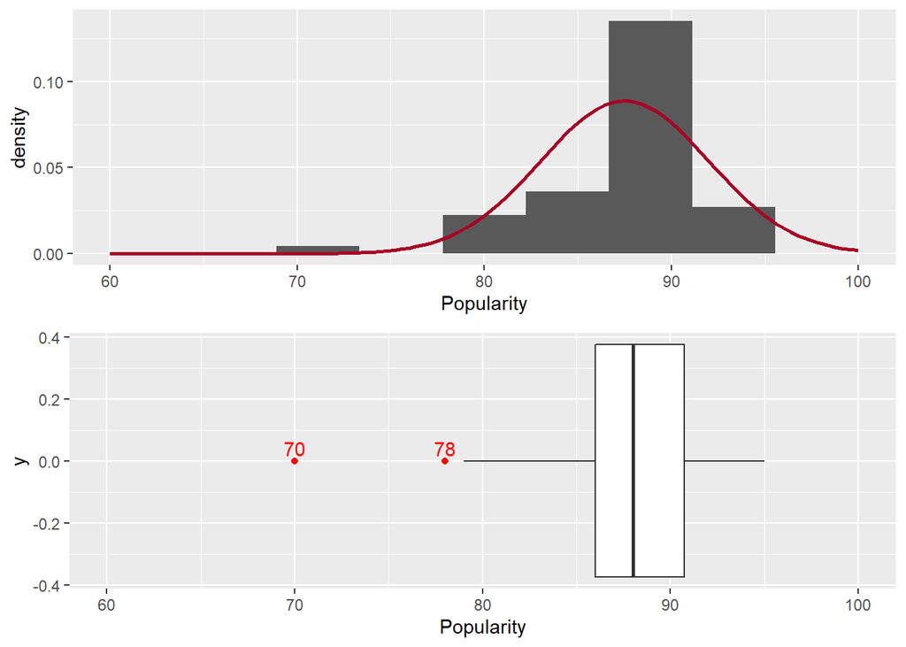

```r
#looking at distribution of Popularity variable
# and annotate outliers in ggplot boxplot
pop.hist <- hist.plots(pop.df, pop.df$Popularity, "Popularity") +
            scale_x_continuous(limits=c(60, 100))
pop.box <-  ggplot(pop.df, aes(x=Popularity)) +
            geom_boxplot(outlier.colour = "red") +
            scale_x_continuous(limits=c(60, 100)) +
            annotate(geom="text", x=70, y=.04, label="70", color="red") +
            annotate(geom="text", x=78, y=.04, label="78", color="red")

gridExtra::grid.arrange(pop.hist, pop.box, nrow=2)
```

```r
#based on interquartile range, capping/flooring outliers in Popularity
IQR.low = stats::quantile(pop.df$Popularity, .25) - 1.5*stats::IQR(pop.df$Popularity)
pop.cap <- round(IQR.low)
pop.df$Popularity <- DescTools::Winsorize(pop.df$Popularity, minval = 79, maxval = 95)

psych::describe(pop.df$Popularity)
```

```
   vars  n mean   sd median trimmed  mad min max range  skew kurtosis   se
X1    1 50 87.7 3.87     88      88 3.71  79  95    16 -0.64    -0.19 0.55
```

To reduce left skewness, power transformations, such as squares or cubes are recommended. reference: http://fmwww.bc.edu/repec/bocode/t/transint.html

```r
#transform
pop.df$Popularity = (pop.df$Popularity)^3
pop.df$Popularity = (pop.df$Popularity)/1e4 #put back onto a similar scale
psych::describe(pop.df$Popularity)
```

```
   vars  n  mean  sd median trimmed  mad  min   max range  skew kurtosis   se
X1    1 50 67.84 8.7  68.15   68.31 8.52 49.3 85.74 36.43 -0.45    -0.34 1.23
```

Let’s take a look at the correlations of Population and the available features

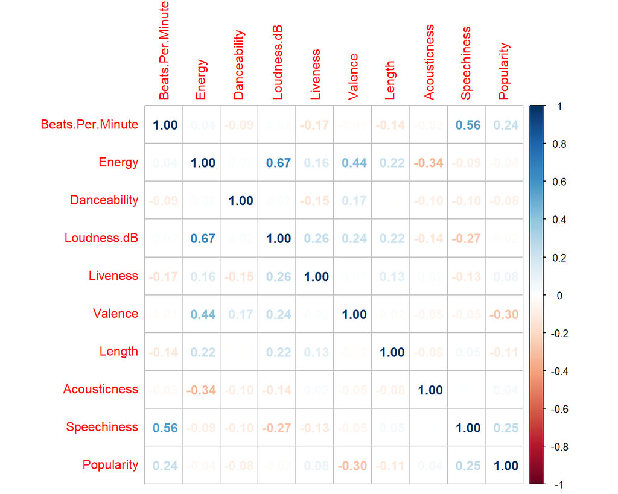

```r
library(corrplot)

#selecting numeric features/variables
cor.data <- stats::cor(pop.df[, sapply(pop.df, is.numeric)])
corrplot(cor.data,method='number')
```

## Distributions (histograms) of potential features

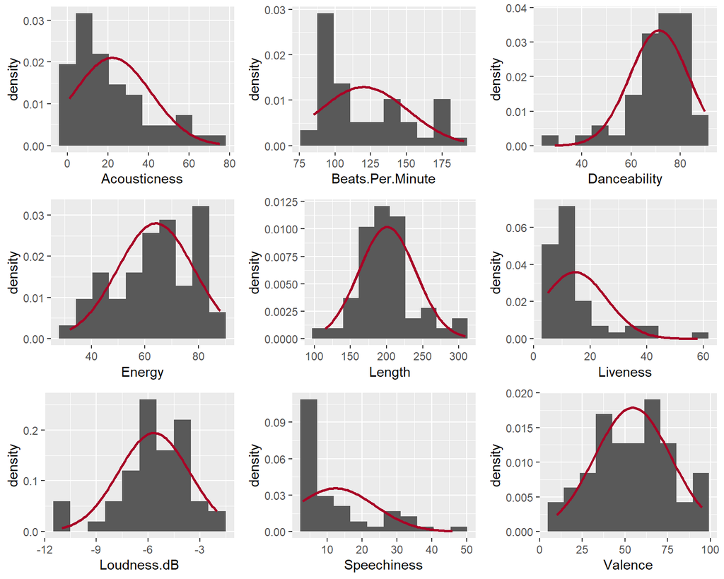

```r
p1 <- hist.plots(pop.df, pop.df$Acousticness, "Acousticness")
p2 <- hist.plots(pop.df, pop.df$Beats.Per.Minute, "Beats.Per.Minute")
p3 <- hist.plots(pop.df, pop.df$Danceability, "Danceability")
p4 <- hist.plots(pop.df, pop.df$Energy, "Energy")
p5 <- hist.plots(pop.df, pop.df$Length, "Length")
p6 <- hist.plots(pop.df, pop.df$Liveness, "Liveness")
p7 <- hist.plots(pop.df, pop.df$Loudness.dB, "Loudness.dB")
p8 <- hist.plots(pop.df, pop.df$Speechiness, "Speechiness")
p9 <- hist.plots(pop.df, pop.df$Valence, "Valence")

gridExtra::grid.arrange(p1, p2, p3, p4, p5, p6, p7, p8, p9, nrow = 3)
```

Many of the features have fairly skewed distributions, so let’s automate the process for finding the best transformation for each variable.  
Method: *Raymaekers, J., & Rousseeuw, P. J. (2021). Transforming variables to central normality. Machine Learning, 1-23.* available at: https://link.springer.com/article/10.1007/s10994-021-05960-5

```r
library(cellWise)

#subsetting features to be transformed
trans.am<- subset(pop.df, select= c('Acousticness','Beats.Per.Minute','Danceability',
                                    'Energy','Length','Liveness','Loudness.dB',
                                    'Valence'))

# type="bestObj" will choose between
# Box-Cox or Yeo-Johnson transformation for each variable
# robust=TRUE, Reweighted Maximum Likelihood method is used
# to choose λ for each variable transformation
auto.pontiac <- cellWise::transfo(trans.am, type = "bestObj", robust=TRUE)
```

```
 The input data has 50 rows and 8 columns.
```

```r
# Note: First run of the transfo function returned the following warning:
# It is recommended not to transform the variable Speechiness or to do so manually.

#export transformed scores
firebird.df <-as.data.frame(auto.pontiac$Xt)

#export info on what type of transformation was used for each variable
fire.bird <-as.data.frame(auto.pontiac$ttypes)
names(fire.bird)[names(fire.bird)=="auto.pontiac$ttypes"] <- "ttype"

# collect info on how each variable was transformed
fire.bird$var.name <- c('Acousticness','Beats.Per.Minute','Danceability',
                        'Energy','Length','Liveness','Loudness.dB',
                        'Valence')

smash <- function(var,t.type) {
  paste(var," (",t.type,")", sep="")  }

fire.bird$var.t<-smash(fire.bird$var.name,fire.bird$ttype)

#  To reduce right skewness, roots, logarithms, or reciprocals are recommended.
pop.df$logSpeechiness = log(pop.df$Speechiness)
```

Now we can take a look at the results of the transformations, including whether Box-Cox or Yeo-Johnson transformations were applied.

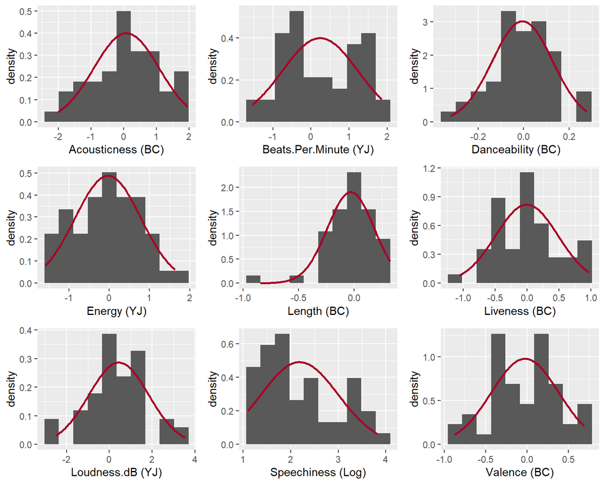

```r
# Draw histograms for transformed variables
# Pull feature name and transformation type from fire.bird
tr1 <- hist.plots(firebird.df, firebird.df$Acousticness, fire.bird[1,3])
tr2 <- hist.plots(firebird.df, firebird.df$Beats.Per.Minute, fire.bird[2,3])
tr3 <- hist.plots(firebird.df, firebird.df$Danceability, fire.bird[3,3])
tr4 <- hist.plots(firebird.df, firebird.df$Energy, fire.bird[4,3])
tr5 <- hist.plots(firebird.df, firebird.df$Length, fire.bird[5,3])
tr6 <- hist.plots(firebird.df, firebird.df$Liveness, fire.bird[6,3])
tr7 <- hist.plots(firebird.df, firebird.df$Loudness.dB, fire.bird[7,3])
tr8 <- hist.plots(pop.df, pop.df$logSpeechiness, "Speechiness (Log)")
tr9 <- hist.plots(firebird.df, firebird.df$Valence, fire.bird[8,3])

gridExtra::grid.arrange(tr1, tr2, tr3, tr4, tr5, tr6, tr7, tr8, tr9, nrow = 3)
```

```r
#collect transformed variables into the same data frame
pop.part1 <- subset(pop.df, select = c('logSpeechiness','Popularity'))
pop.dft.num <- cbind(firebird.df,pop.part1)
knitr::kable(describe(pop.dft.num), digits=2)
```

|  | vars | n | mean | sd | median | trimmed | mad | min | max | range | skew | kurtosis | se |
| --- | --- | --- | --- | --- | --- | --- | --- | --- | --- | --- | --- | --- | --- |
| Acousticness | 1 | 50 | 0.08 | 0.99 | 0.00 | 0.09 | 1.04 | -2.01 | 1.95 | 3.96 | -0.06 | -0.83 | 0.14 |
| Beats.Per.Minute | 2 | 50 | 0.24 | 1.00 | 0.00 | 0.24 | 1.18 | -1.55 | 1.86 | 3.41 | 0.09 | -1.33 | 0.14 |
| Danceability | 3 | 50 | -0.01 | 0.13 | 0.00 | 0.00 | 0.13 | -0.32 | 0.28 | 0.60 | -0.20 | -0.26 | 0.02 |
| Energy | 4 | 50 | -0.03 | 0.82 | 0.00 | -0.03 | 0.89 | -1.59 | 1.63 | 3.23 | -0.02 | -0.97 | 0.12 |
| Length | 5 | 50 | -0.03 | 0.21 | 0.00 | -0.02 | 0.15 | -0.84 | 0.32 | 1.17 | -1.28 | 3.22 | 0.03 |
| Liveness | 6 | 50 | 0.00 | 0.49 | 0.00 | -0.01 | 0.53 | -1.06 | 0.97 | 2.03 | 0.10 | -0.67 | 0.07 |
| Loudness.dB | 7 | 50 | 0.44 | 1.39 | 0.00 | 0.44 | 1.10 | -2.50 | 3.55 | 6.05 | 0.00 | -0.15 | 0.20 |
| Valence | 8 | 50 | -0.03 | 0.41 | 0.00 | -0.02 | 0.45 | -0.88 | 0.69 | 1.57 | -0.13 | -0.89 | 0.06 |
| logSpeechiness | 9 | 50 | 2.18 | 0.81 | 1.95 | 2.14 | 0.81 | 1.10 | 3.83 | 2.73 | 0.44 | -1.03 | 0.11 |
| Popularity | 10 | 50 | 67.84 | 8.70 | 68.15 | 68.31 | 8.52 | 49.30 | 85.74 | 36.43 | -0.45 | -0.34 | 1.23 |

```r
#check for outliers
DescTools::Outlier(pop.dft.num$Length)
```

```
[1] -0.5744456 -0.8440580
```

```r
IQR.low = stats::quantile(pop.dft.num$Length, .25) - 1.5*stats::IQR(pop.dft.num$Length)

# cap any remaining outliers to minimum value to retain all data points
pop.dft.num$Length <- DescTools::Winsorize(pop.dft.num$Length,
                                           minval =-0.315553293,
                                           maxval = 0.323574509)
```

There is an additional, categorical feature to consider: music genre.

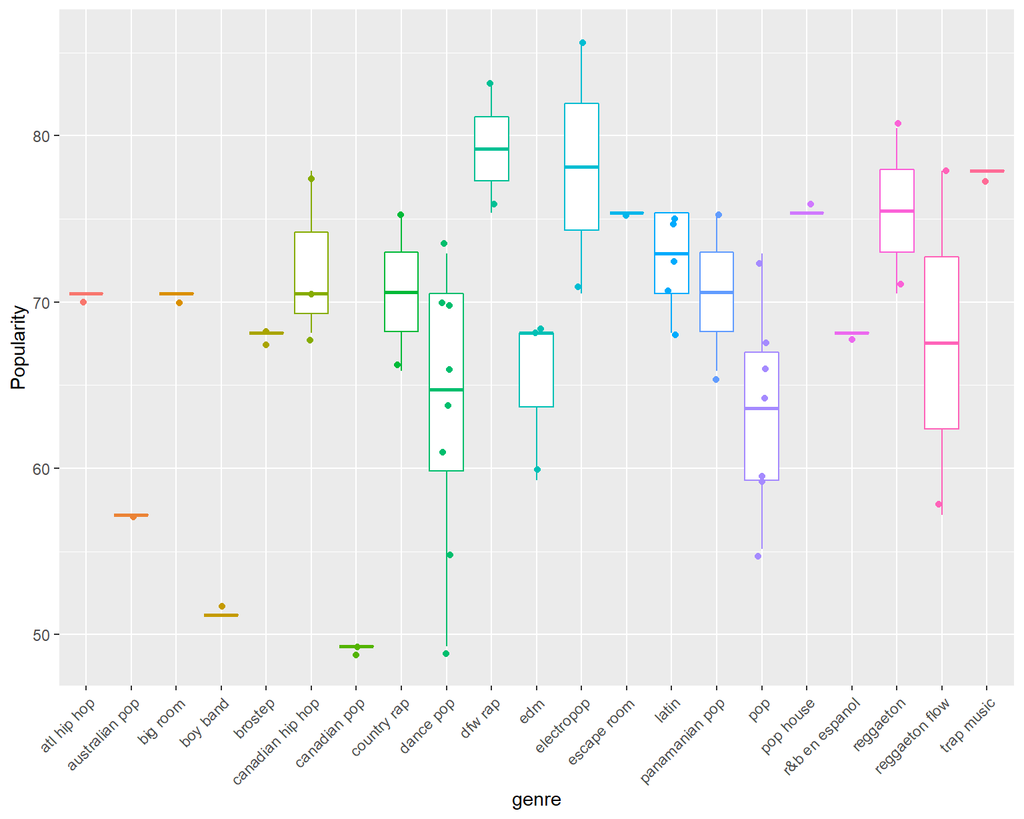

```r
#add categorical variable to data frame
pop.dft <- pop.dft.num
pop.dft$genre <-pop.df[, c(3)]

bp1 <-ggplot2::ggplot(pop.dft, aes(x=genre, y=Popularity, color=genre))
bp1 <- bp1 + geom_boxplot() + geom_jitter(width=0.10) + theme(legend.position = "none")
bp1 <- bp1 + theme(axis.text.x = element_text(angle = 45, hjust = 1))
bp1
```

```r
unique(pop.dft$genre)
```

```
 [1] "canadian pop"     "reggaeton flow"   "dance pop"        "pop"
 [5] "dfw rap"          "trap music"       "country rap"      "electropop"
 [9] "reggaeton"        "panamanian pop"   "canadian hip hop" "latin"
[13] "escape room"      "pop house"        "australian pop"   "edm"
[17] "atl hip hop"      "big room"         "boy band"         "r&b en espanol"
[21] "brostep"
```

```r
#re-coding genre to pop vs other
pop.dft$genre.2 <- ifelse(pop.dft$genre == "pop", "pop",
                    ifelse(pop.dft$genre == "canadian pop", "pop",
                    ifelse(pop.dft$genre == "dance pop", "pop",
                    ifelse(pop.dft$genre == "electropop", "pop",
                    ifelse(pop.dft$genre == "pop house", "pop",
                    ifelse(pop.dft$genre == "panamanian pop", "pop",
                    ifelse(pop.dft$genre == "australian pop", "pop", "other")))))))
```

```r
# add t-test results to box plot to include more info on group differences
stats::t.test(pop.dft$Popularity ~ pop.dft$genre.2)
```

[output not shown]

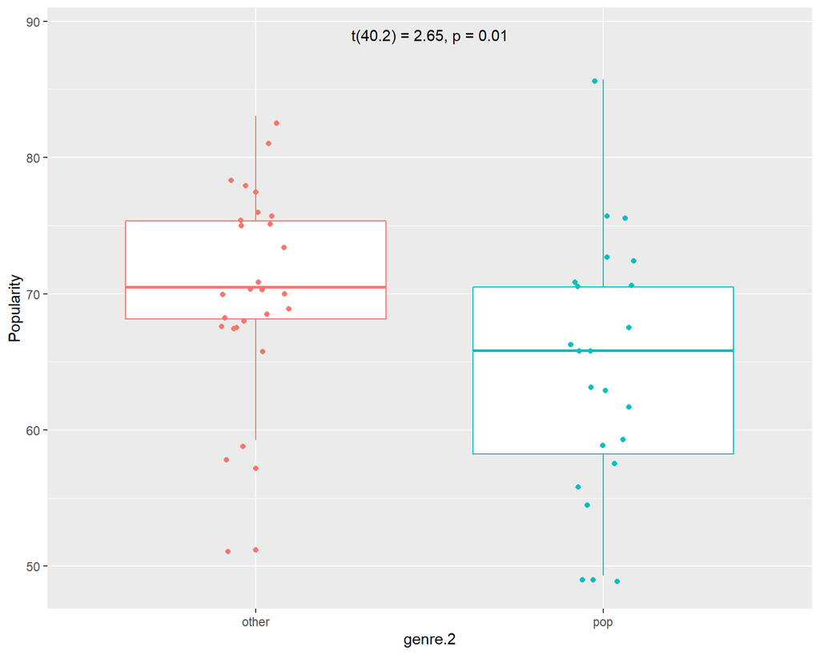

```r
bp2 <-ggplot2::ggplot(pop.dft, aes(x=genre.2, y=Popularity, color=genre.2))
bp2 <- bp2 + geom_boxplot() + geom_jitter(width=0.10) + theme(legend.position = "none")
bp2 <- bp2 + annotate(geom="text", x=1.5, y=89, label="t(40.2) = 2.65, p = 0.01", color="black")
bp2
```

```r
#designate new genre variable as factor
pop.dft$genre.2 <- as.factor(pop.dft$genre.2)
#remove previous version of genre from data frame
pop.dft <-pop.dft[-c(11)]
# double check new file structure
str(pop.dft)
```

```
'data.frame':   50 obs. of  11 variables:
 $ Acousticness    : num  -1.137 -0.585 -0.217 -0.217 1.252 ...
 $ Beats.Per.Minute: num  0.5271 0.0267 1.859 -0.7939 1.308 ...
 $ Danceability    : num  0.0351 0.0803 -0.2847 -0.1139 -0.171 ...
 $ Energy          : num  -0.623 1.0389 0.9586 -0.0902 -0.0902 ...
 $ Length          : num  -0.037 0.3117 -0.0656 0 -0.1358 ...
 $ Liveness        : num  -0.358 -0.358 0.328 -0.358 0 ...
 $ Loudness.dB     : num  0 1.6 1.6 -1.15 1.6 ...
 $ Valence         : num  0.34554 0.0986 0.25796 -0.00901 -0.7097 ...
 $ logSpeechiness  : num  1.1 2.2 3.83 2.94 1.95 ...
 $ Popularity      : num  49.3 77.9 61.4 63.6 83.1 ...
 $ genre.2         : Factor w/ 2 levels "other","pop": 2 1 2 2 1 2 1 2 1 2 ...
```

```r
# get rid of some unnecessary objects
rm(pop.df)
rm(pop.dft.num)
rm(firebird.df)
rm(fire.bird)
rm(pop.part1)
rm(tr1, tr2, tr3, tr4, tr5, tr6, tr7, tr8, tr9)
rm(p1, p2, p3, p4, p5, p6, p7, p8, p9)
```

Now we need to split the data and normalize the variables before training.

```r
library(caTools)
library(caret) # for z-scoring test & train sets

# Setting a random seed so results are reproducible
set.seed(123)

# creating train and test data sets
# Split up the sample, basically randomly assigns a Boolean value to a new column "sample"
sample <- sample.split(pop.dft$Length, SplitRatio = .7 )
# Training Data
train = subset(pop.dft, sample == TRUE)
# Testing Data
test = subset(pop.dft, sample == FALSE)

# save out mean and sd from training data to use for z-scoring
# both train and test data sets
zscore.train <- preProcess(train, method = c("center", "scale"))
train.z <-predict(zscore.train, train)
test.z <-predict(zscore.train, test)

knitr::kable(psych::describe(train.z, check=TRUE), digits=3)
```

|  | vars | n | mean | sd | median | trimmed | mad | min | max | range | skew | kurtosis | se |
| --- | --- | --- | --- | --- | --- | --- | --- | --- | --- | --- | --- | --- | --- |
| Acousticness | 1 | 35 | 0.000 | 1.000 | 0.152 | 0.003 | 1.052 | -2.024 | 1.905 | 3.929 | -0.078 | -0.833 | 0.169 |
| Beats.Per.Minute | 2 | 35 | 0.000 | 1.000 | -0.256 | -0.003 | 1.156 | -1.801 | 1.663 | 3.464 | 0.176 | -1.313 | 0.169 |
| Danceability | 3 | 35 | 0.000 | 1.000 | 0.044 | 0.009 | 1.036 | -2.289 | 1.994 | 4.282 | -0.108 | -0.446 | 0.169 |
| Energy | 4 | 35 | 0.000 | 1.000 | 0.171 | -0.024 | 1.264 | -1.515 | 2.000 | 3.515 | 0.084 | -1.067 | 0.169 |
| Length | 5 | 35 | 0.000 | 1.000 | 0.094 | -0.020 | 0.988 | -1.721 | 2.213 | 3.933 | 0.032 | -0.655 | 0.169 |
| Liveness | 6 | 35 | 0.000 | 1.000 | 0.000 | -0.002 | 1.012 | -2.025 | 1.848 | 3.873 | -0.021 | -0.871 | 0.169 |
| Loudness.dB | 7 | 35 | 0.000 | 1.000 | -0.353 | -0.001 | 0.780 | -2.125 | 2.167 | 4.292 | 0.099 | -0.012 | 0.169 |
| Valence | 8 | 35 | 0.000 | 1.000 | 0.004 | 0.017 | 1.156 | -2.387 | 1.679 | 4.066 | -0.182 | -0.713 | 0.169 |
| logSpeechiness | 9 | 35 | 0.000 | 1.000 | -0.374 | -0.068 | 0.920 | -1.216 | 2.100 | 3.315 | 0.640 | -0.842 | 0.169 |
| Popularity | 10 | 35 | 0.000 | 1.000 | 0.116 | 0.052 | 0.435 | -2.235 | 2.310 | 4.545 | -0.439 | 0.187 | 0.169 |
| genre.2* | 11 | 35 | 1.429 | 0.502 | 1.000 | 1.414 | 0.000 | 1.000 | 2.000 | 1.000 | 0.276 | -1.978 | 0.085 |

## Lasso Regression

Since sample size is small with quite a few features, let’s use Lasso regression to help with variable selection.

```r
#lasso analysis
library(glmnet)
library(Matrix)

# Prepping data for model.
# Decided to exclude Beats.Per.Minute as it is fairly correlated with Speechiness (0.56)
x <- data.matrix(train.z[, -c(2,7,10)])
y <- train.z$Popularity

# using folds=35 to set up LOOVC
cv_model <- glmnet::cv.glmnet(x=x, y=y, alpha = 1, folds=35, standardize=FALSE)
print(cv_model)
```

```
Call:  glmnet::cv.glmnet(x = x, y = y, alpha = 1, folds = 35, standardize = FALSE)

Measure: Mean-Squared Error

     Lambda Index Measure     SE Nonzero
min 0.06888    17  0.9825 0.2713       5
1se 0.30519     1  1.0647 0.2428       0
```

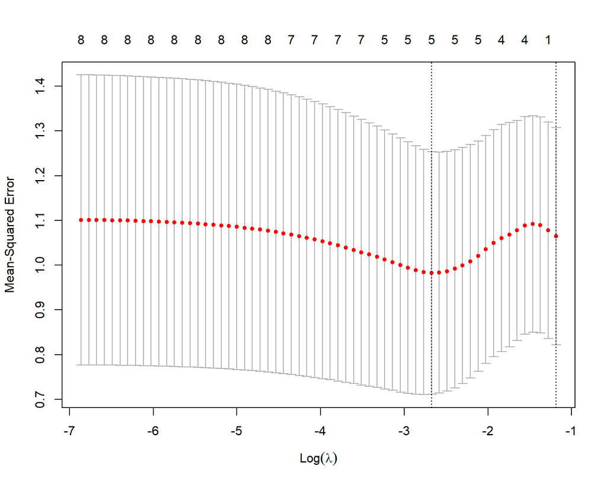

```r
plot(cv_model)
```

```r
best_lambda <- cv_model$lambda.min
best_lambda
```

```
[1] 0.0688815
```

```r
log(best_lambda)
```

```
[1] -2.675368
```

```r
#save out best model for prediction
best_model <- glmnet::glmnet(x, y, alpha = 1, lambda = best_lambda)
coef(best_model)
```

```
9 x 1 sparse Matrix of class "dgCMatrix"
                       s0
(Intercept)     0.6614704
Acousticness    .
Danceability   -0.2272366
Energy          .
Length         -0.1604775
Liveness        .
Valence        -0.2517731
logSpeechiness  0.2166586
genre.2        -0.4630293
```

## Visualization of how each feature performed in the Lasso analysis

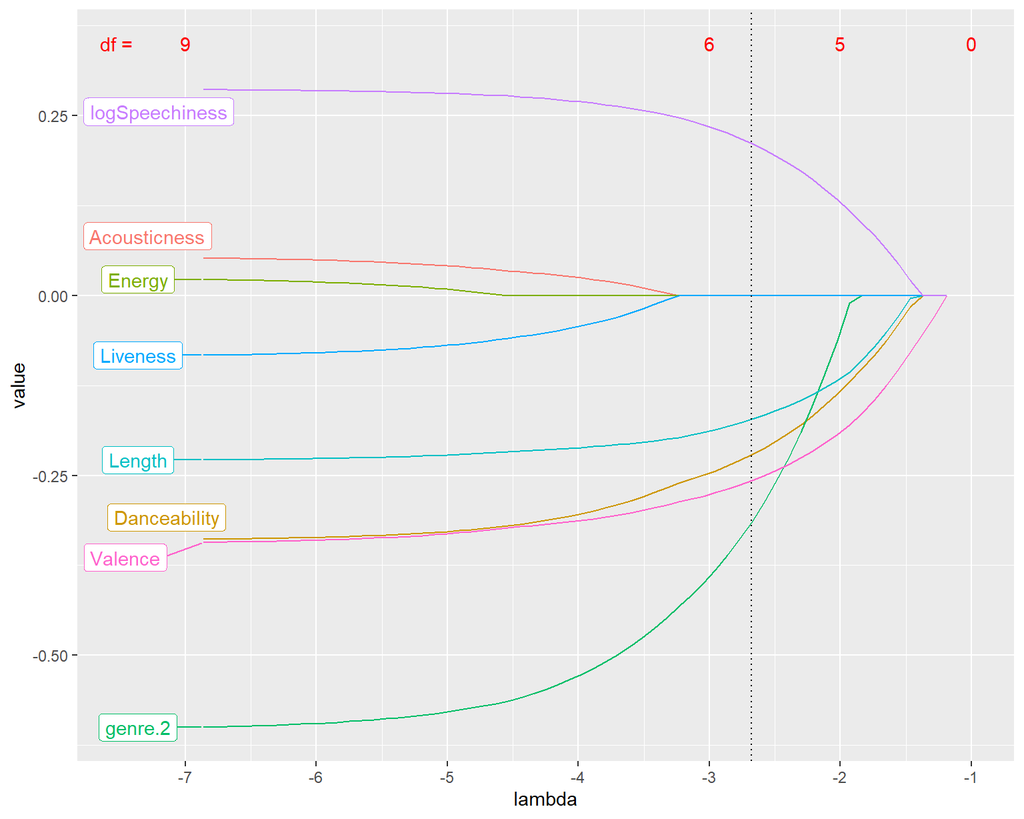

```r
library(tidyr)
library(ggrepel)

#get data out to plot how features performed in CV
betas = as.matrix(cv_model$glmnet.fit$beta)
lambdas = log(cv_model$lambda)
names(lambdas) = colnames(betas)

as.data.frame(betas) %>%
  tibble::rownames_to_column("variable") %>%
  pivot_longer(-variable) %>%
  mutate(lambda=lambdas[name]) %>%
  ggplot(aes(x=lambda,y=value,col=variable)) + theme(legend.position = "none") +
  geom_line() + scale_y_continuous(breaks = seq(-.75, .50, by = .25)) +
  scale_x_continuous(breaks = seq(-1, -8, by = -1)) +
  geom_label_repel(data=~subset(.x,lambda==min(lambda)),
                   aes(label=variable),nudge_x=-0.5) +
  annotate(geom="text", x=-7.5, y=.35 , label="df = ", color="red") +
  annotate(geom="text", x=-7, y=.35 , label="9", color="red") +
  annotate(geom="text", x=-3, y=.35 , label="6", color="red") +
  annotate(geom="text", x=-2, y=.35 , label="5", color="red") +
  annotate(geom="text", x=-1, y=.35 , label="0", color="red") +
  geom_vline(xintercept=c(-2.68), linetype="dotted")
```

Let’s take a look at R squared in the training set

```r
#get r squared values for training data
y.pred.train <-stats::predict(best_model, x)

train.sst <- sum((y - mean(y))^2)
train.sse <- sum((y - y.pred.train)^2)

#use SST and SSE to calculate R-Squared
train.rsq <- 1 - train.sse/train.sst
train.Rsq <-round(train.rsq, digits=3)
train.Rsq
```

```
[1] 0.379
```

## Test set performance

```r
#prep test data set to predict with best model
test.x <- data.matrix(test.z[,-c(2,7,10)])
test.y  <- test.z$Popularity

#use fitted best model to make predictions on test set
y.pred <- stats::predict(best_model, newx = test.x)

#find Test SST and SSE
test.sst <- sum((test.y - mean(test.y))^2)
test.sse <- sum((test.y - y.pred)^2)

#use SST and SSE to calculate Test R-Squared
test.rsq <- 1 - test.sse/test.sst
test.Rsq <-round(test.rsq, digits=3)

#Test MSE
test.int.model.MSE <-round(mean((mean(y) - test.y)^2), digits=3)
test.best.model.MSE <-round(mean((y.pred - test.y)^2), digits=3)

test.samp <-data.frame(test.int.model.MSE, test.best.model.MSE, test.Rsq)

kbl(test.samp) %>%
  kable_paper("hover", full_width = F)
```

| test.int.model.MSE | test.best.model.MSE | test.Rsq |
| --- | --- | --- |
| 1.605 | 1.368 | 0.111 |